# Risk Factor Analysis

## Outcome Variable

**Outcome Variable:** sstunted

## Predictor Variables

**Intervention Variable:** predfeed36

**Adjustment Set:**

- arm
- sex
- month
- brthmon
- W_mage
- meducyrs
- feducyrs
- hhwealth_quart
- hfoodsec
- W_mhtcm
- vagbrth
- W_gagebrth
- W_birthwt
- W_birthlen
- W_nrooms
- W_nchldlt5
- W_parity
- impfloor
- impsan
- safeh20
- delta_W_mage
- delta_meducyrs
- delta_feducyrs
- delta_hhwealth_quart
- delta_hfoodsec
- delta_W_mhtcm
- delta_vagbrth
- delta_W_gagebrth
- delta_W_birthwt
- delta_W_birthlen
- delta_W_nrooms
- delta_W_nchldlt5
- delta_W_parity
- delta_impfloor
- delta_impsan
- delta_safeh20

## Stratifying Variables

The analysis was stratified on these variable(s):

- agecat
- studyid
- country

## Data Summary

| agecat | studyid | country | predfeed36 | sstunted | n_cell | n |
| --- | --- | --- | --- | --- | --- | --- |
| Birth | ki0047075b-MAL-ED | BANGLADESH | 1 | 0 | 123 | 243 |
| Birth | ki0047075b-MAL-ED | BANGLADESH | 1 | 1 | 2 | 243 |
| Birth | ki0047075b-MAL-ED | BANGLADESH | 0 | 0 | 113 | 243 |
| Birth | ki0047075b-MAL-ED | BANGLADESH | 0 | 1 | 5 | 243 |
| Birth | ki0047075b-MAL-ED | BRAZIL | 1 | 0 | 27 | 185 |
| Birth | ki0047075b-MAL-ED | BRAZIL | 1 | 1 | 2 | 185 |
| Birth | ki0047075b-MAL-ED | BRAZIL | 0 | 0 | 150 | 185 |
| Birth | ki0047075b-MAL-ED | BRAZIL | 0 | 1 | 6 | 185 |
| Birth | ki0047075b-MAL-ED | INDIA | 1 | 0 | 14 | 198 |
| Birth | ki0047075b-MAL-ED | INDIA | 1 | 1 | 2 | 198 |
| Birth | ki0047075b-MAL-ED | INDIA | 0 | 0 | 177 | 198 |
| Birth | ki0047075b-MAL-ED | INDIA | 0 | 1 | 5 | 198 |
| Birth | ki0047075b-MAL-ED | NEPAL | 1 | 0 | 25 | 172 |
| Birth | ki0047075b-MAL-ED | NEPAL | 1 | 1 | 1 | 172 |
| Birth | ki0047075b-MAL-ED | NEPAL | 0 | 0 | 141 | 172 |
| Birth | ki0047075b-MAL-ED | NEPAL | 0 | 1 | 5 | 172 |
| Birth | ki0047075b-MAL-ED | PERU | 1 | 0 | 116 | 273 |
| Birth | ki0047075b-MAL-ED | PERU | 1 | 1 | 2 | 273 |
| Birth | ki0047075b-MAL-ED | PERU | 0 | 0 | 151 | 273 |
| Birth | ki0047075b-MAL-ED | PERU | 0 | 1 | 4 | 273 |
| Birth | ki0047075b-MAL-ED | SOUTH AFRICA | 1 | 0 | 3 | 236 |
| Birth | ki0047075b-MAL-ED | SOUTH AFRICA | 1 | 1 | 0 | 236 |
| Birth | ki0047075b-MAL-ED | SOUTH AFRICA | 0 | 0 | 232 | 236 |
| Birth | ki0047075b-MAL-ED | SOUTH AFRICA | 0 | 1 | 1 | 236 |
| Birth | ki0047075b-MAL-ED | TANZANIA, UNITED REPUBLIC OF | 1 | 0 | 1 | 121 |
| Birth | ki0047075b-MAL-ED | TANZANIA, UNITED REPUBLIC OF | 1 | 1 | 0 | 121 |
| Birth | ki0047075b-MAL-ED | TANZANIA, UNITED REPUBLIC OF | 0 | 0 | 114 | 121 |
| Birth | ki0047075b-MAL-ED | TANZANIA, UNITED REPUBLIC OF | 0 | 1 | 6 | 121 |
| Birth | ki1000109-EE | PAKISTAN | 1 | 0 | 1 | 2 |
| Birth | ki1000109-EE | PAKISTAN | 1 | 1 | 0 | 2 |

[output cut: 106 more lines]

The following strata were considered:

- agecat: 24 months, studyid: ki0047075b-MAL-ED, country: BANGLADESH
- agecat: 24 months, studyid: ki0047075b-MAL-ED, country: BRAZIL
- agecat: 24 months, studyid: ki0047075b-MAL-ED, country: INDIA
- agecat: 24 months, studyid: ki0047075b-MAL-ED, country: NEPAL
- agecat: 24 months, studyid: ki0047075b-MAL-ED, country: PERU
- agecat: 24 months, studyid: ki0047075b-MAL-ED, country: SOUTH AFRICA
- agecat: 24 months, studyid: ki0047075b-MAL-ED, country: TANZANIA, UNITED REPUBLIC OF
- agecat: 24 months, studyid: ki1113344-GMS-Nepal, country: NEPAL
- agecat: 24 months, studyid: ki1148112-LCNI-5, country: MALAWI
- agecat: 24 months, studyid: kiGH5241-JiVitA-3, country: BANGLADESH
- agecat: 24 months, studyid: kiGH5241-JiVitA-4, country: BANGLADESH
- agecat: 6 months, studyid: ki0047075b-MAL-ED, country: BANGLADESH
- agecat: 6 months, studyid: ki0047075b-MAL-ED, country: BRAZIL
- agecat: 6 months, studyid: ki0047075b-MAL-ED, country: INDIA
- agecat: 6 months, studyid: ki0047075b-MAL-ED, country: NEPAL
- agecat: 6 months, studyid: ki0047075b-MAL-ED, country: PERU
- agecat: 6 months, studyid: ki0047075b-MAL-ED, country: SOUTH AFRICA
- agecat: 6 months, studyid: ki0047075b-MAL-ED, country: TANZANIA, UNITED REPUBLIC OF
- agecat: 6 months, studyid: ki1000109-EE, country: PAKISTAN
- agecat: 6 months, studyid: ki1000304b-SAS-FoodSuppl, country: INDIA
- agecat: 6 months, studyid: ki1113344-GMS-Nepal, country: NEPAL
- agecat: 6 months, studyid: ki1148112-LCNI-5, country: MALAWI
- agecat: 6 months, studyid: kiGH5241-JiVitA-3, country: BANGLADESH
- agecat: 6 months, studyid: kiGH5241-JiVitA-4, country: BANGLADESH
- agecat: Birth, studyid: ki0047075b-MAL-ED, country: BANGLADESH
- agecat: Birth, studyid: ki0047075b-MAL-ED, country: BRAZIL
- agecat: Birth, studyid: ki0047075b-MAL-ED, country: INDIA
- agecat: Birth, studyid: ki0047075b-MAL-ED, country: NEPAL
- agecat: Birth, studyid: ki0047075b-MAL-ED, country: PERU
- agecat: Birth, studyid: ki0047075b-MAL-ED, country: SOUTH AFRICA
- agecat: Birth, studyid: ki0047075b-MAL-ED, country: TANZANIA, UNITED REPUBLIC OF
- agecat: Birth, studyid: ki1000109-EE, country: PAKISTAN
- agecat: Birth, studyid: kiGH5241-JiVitA-3, country: BANGLADESH
- agecat: Birth, studyid: kiGH5241-JiVitA-4, country: BANGLADESH

### Dropped Strata

Some strata were dropped due to rare outcomes:

- agecat: Birth, studyid: ki0047075b-MAL-ED, country: BANGLADESH
- agecat: Birth, studyid: ki0047075b-MAL-ED, country: BRAZIL
- agecat: Birth, studyid: ki0047075b-MAL-ED, country: INDIA
- agecat: Birth, studyid: ki0047075b-MAL-ED, country: NEPAL
- agecat: Birth, studyid: ki0047075b-MAL-ED, country: PERU
- agecat: Birth, studyid: ki0047075b-MAL-ED, country: SOUTH AFRICA
- agecat: Birth, studyid: ki0047075b-MAL-ED, country: TANZANIA, UNITED REPUBLIC OF
- agecat: Birth, studyid: ki1000109-EE, country: PAKISTAN
- agecat: 6 months, studyid: ki0047075b-MAL-ED, country: BANGLADESH
- agecat: 6 months, studyid: ki0047075b-MAL-ED, country: BRAZIL
- agecat: 6 months, studyid: ki0047075b-MAL-ED, country: INDIA
- agecat: 6 months, studyid: ki0047075b-MAL-ED, country: NEPAL
- agecat: 6 months, studyid: ki0047075b-MAL-ED, country: PERU
- agecat: 6 months, studyid: ki0047075b-MAL-ED, country: SOUTH AFRICA
- agecat: 6 months, studyid: ki0047075b-MAL-ED, country: TANZANIA, UNITED REPUBLIC OF
- agecat: 6 months, studyid: ki1000304b-SAS-FoodSuppl, country: INDIA
- agecat: 6 months, studyid: ki1148112-LCNI-5, country: MALAWI
- agecat: 24 months, studyid: ki0047075b-MAL-ED, country: BRAZIL
- agecat: 24 months, studyid: ki0047075b-MAL-ED, country: NEPAL
- agecat: 24 months, studyid: ki0047075b-MAL-ED, country: PERU
- agecat: 24 months, studyid: ki0047075b-MAL-ED, country: SOUTH AFRICA
- agecat: 24 months, studyid: ki0047075b-MAL-ED, country: TANZANIA, UNITED REPUBLIC OF
- agecat: 24 months, studyid: ki1148112-LCNI-5, country: MALAWI

## Methods Detail

We’re interested in the causal parameters $E[Y_a]$ for all values of $a \in \mathcal{A}$. These parameters represent the mean outcome if, possibly contrary to fact, we intervened to set all units to have $A=a$. Under the randomization and positivity assumptions, these are identified by the statistical parameters $\psi_a=E_W[E_{Y|A,W}(Y|A=a,W)]$. In addition, we’re interested in the mean of $Y$, $E[Y]$ under no intervention (the observed mean). We will estimate these parameters by using SuperLearner to fit the relevant likelihood factors – $E_{Y|A,W}(Y|A=a,W)$ and $p(A=a|W)$, and then updating our likelihood fit using a joint TMLE.

For unadjusted analyses ($W=\{\}$), initial likelihoods were estimated using Lrnr_glm to estimate the simple $E(Y|A)$ and Lrnr_mean to estimate $p(A)$. For adjusted analyses, a small library containing Lrnr_glmnet, Lrnr_xgboost, and Lrnr_mean was used.

Having estimated these parameters, we will then use the delta method to estimate relative risks and attributable risks relative to a prespecified baseline level of $A$.

# Results Detail

## Results Plots

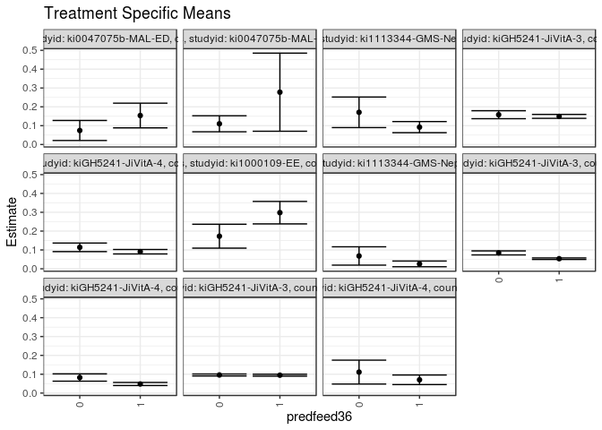

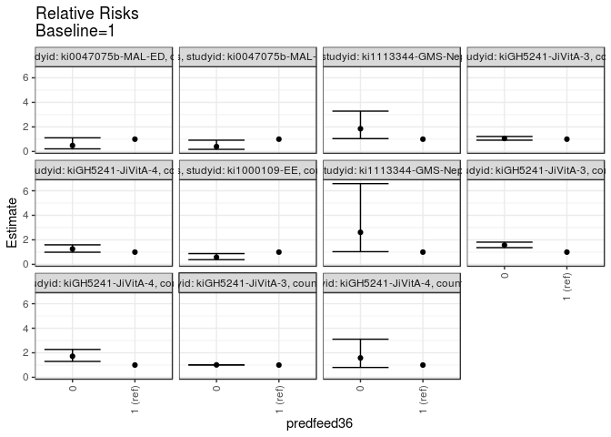

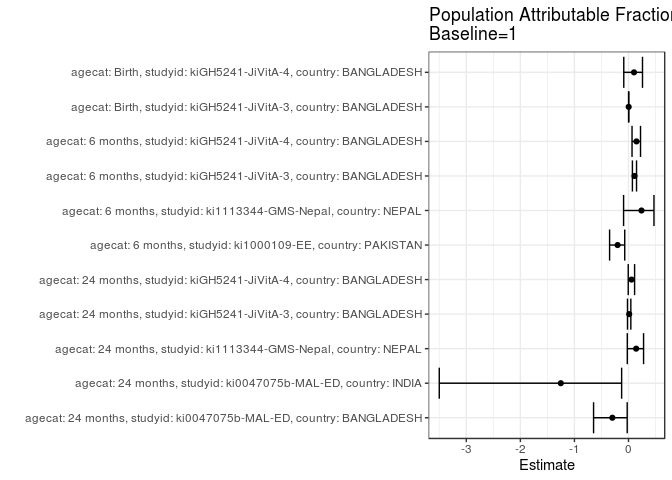

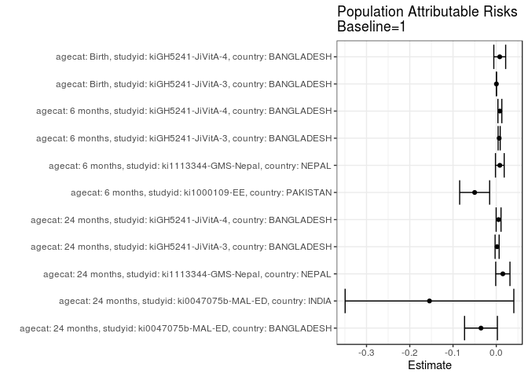

## Results Table

### Parameter: TSM

| agecat | studyid | country | intervention_level | baseline_level | estimate | ci_lower | ci_upper |
| --- | --- | --- | --- | --- | --- | --- | --- |
| Birth | kiGH5241-JiVitA-3 | BANGLADESH | 1 | NA | 0.0948607 | 0.0897833 | 0.0999382 |
| Birth | kiGH5241-JiVitA-3 | BANGLADESH | 0 | NA | 0.0959464 | 0.0907502 | 0.1011425 |
| Birth | kiGH5241-JiVitA-4 | BANGLADESH | 1 | NA | 0.0703987 | 0.0449273 | 0.0958701 |
| Birth | kiGH5241-JiVitA-4 | BANGLADESH | 0 | NA | 0.1112001 | 0.0478140 | 0.1745863 |
| 6 months | ki1000109-EE | PAKISTAN | 1 | NA | 0.2979537 | 0.2382815 | 0.3576259 |
| 6 months | ki1000109-EE | PAKISTAN | 0 | NA | 0.1729195 | 0.1095010 | 0.2363381 |
| 6 months | ki1113344-GMS-Nepal | NEPAL | 1 | NA | 0.0260047 | 0.0108239 | 0.0411856 |
| 6 months | ki1113344-GMS-Nepal | NEPAL | 0 | NA | 0.0679612 | 0.0193104 | 0.1166120 |
| 6 months | kiGH5241-JiVitA-3 | BANGLADESH | 1 | NA | 0.0535713 | 0.0494294 | 0.0577131 |
| 6 months | kiGH5241-JiVitA-3 | BANGLADESH | 0 | NA | 0.0842522 | 0.0735173 | 0.0949870 |
| 6 months | kiGH5241-JiVitA-4 | BANGLADESH | 1 | NA | 0.0480394 | 0.0398109 | 0.0562680 |
| 6 months | kiGH5241-JiVitA-4 | BANGLADESH | 0 | NA | 0.0824149 | 0.0629445 | 0.1018853 |
| 24 months | ki0047075b-MAL-ED | BANGLADESH | 1 | NA | 0.1538462 | 0.0883140 | 0.2193784 |
| 24 months | ki0047075b-MAL-ED | BANGLADESH | 0 | NA | 0.0744681 | 0.0212699 | 0.1276662 |
| 24 months | ki0047075b-MAL-ED | INDIA | 1 | NA | 0.2777778 | 0.0704036 | 0.4851520 |
| 24 months | ki0047075b-MAL-ED | INDIA | 0 | NA | 0.1100478 | 0.0675264 | 0.1525693 |
| 24 months | ki1113344-GMS-Nepal | NEPAL | 1 | NA | 0.0922879 | 0.0626820 | 0.1218939 |
| 24 months | ki1113344-GMS-Nepal | NEPAL | 0 | NA | 0.1709497 | 0.0898257 | 0.2520737 |
| 24 months | kiGH5241-JiVitA-3 | BANGLADESH | 1 | NA | 0.1494340 | 0.1389768 | 0.1598912 |
| 24 months | kiGH5241-JiVitA-3 | BANGLADESH | 0 | NA | 0.1582288 | 0.1371189 | 0.1793387 |
| 24 months | kiGH5241-JiVitA-4 | BANGLADESH | 1 | NA | 0.0906190 | 0.0787635 | 0.1024745 |
| 24 months | kiGH5241-JiVitA-4 | BANGLADESH | 0 | NA | 0.1139441 | 0.0911807 | 0.1367075 |

### Parameter: E(Y)

| agecat | studyid | country | intervention_level | baseline_level | estimate | ci_lower | ci_upper |
| --- | --- | --- | --- | --- | --- | --- | --- |
| Birth | kiGH5241-JiVitA-3 | BANGLADESH | NA | NA | 0.0951527 | 0.0900508 | 0.1002546 |
| Birth | kiGH5241-JiVitA-4 | BANGLADESH | NA | NA | 0.0784044 | 0.0544827 | 0.1023261 |
| 6 months | ki1000109-EE | PAKISTAN | NA | NA | 0.2479564 | 0.2037162 | 0.2921966 |
| 6 months | ki1113344-GMS-Nepal | NEPAL | NA | NA | 0.0342205 | 0.0186698 | 0.0497713 |
| 6 months | kiGH5241-JiVitA-3 | BANGLADESH | NA | NA | 0.0602617 | 0.0561000 | 0.0644233 |
| 6 months | kiGH5241-JiVitA-4 | BANGLADESH | NA | NA | 0.0563414 | 0.0484727 | 0.0642101 |
| 24 months | ki0047075b-MAL-ED | BANGLADESH | NA | NA | 0.1184834 | 0.0747732 | 0.1621936 |
| 24 months | ki0047075b-MAL-ED | INDIA | NA | NA | 0.1233480 | 0.0804760 | 0.1662200 |
| 24 months | ki1113344-GMS-Nepal | NEPAL | NA | NA | 0.1074561 | 0.0790002 | 0.1359121 |
| 24 months | kiGH5241-JiVitA-3 | BANGLADESH | NA | NA | 0.1513522 | 0.1415495 | 0.1611548 |
| 24 months | kiGH5241-JiVitA-4 | BANGLADESH | NA | NA | 0.0959483 | 0.0853397 | 0.1065568 |

### Parameter: RR

| agecat | studyid | country | intervention_level | baseline_level | estimate | ci_lower | ci_upper |
| --- | --- | --- | --- | --- | --- | --- | --- |
| Birth | kiGH5241-JiVitA-3 | BANGLADESH | 1 | 1 | 1.0000000 | 1.0000000 | 1.0000000 |
| Birth | kiGH5241-JiVitA-3 | BANGLADESH | 0 | 1 | 1.0114444 | 1.0041439 | 1.0187980 |
| Birth | kiGH5241-JiVitA-4 | BANGLADESH | 1 | 1 | 1.0000000 | 1.0000000 | 1.0000000 |
| Birth | kiGH5241-JiVitA-4 | BANGLADESH | 0 | 1 | 1.5795771 | 0.8031101 | 3.1067519 |
| 6 months | ki1000109-EE | PAKISTAN | 1 | 1 | 1.0000000 | 1.0000000 | 1.0000000 |
| 6 months | ki1000109-EE | PAKISTAN | 0 | 1 | 0.5803571 | 0.3828703 | 0.8797087 |
| 6 months | ki1113344-GMS-Nepal | NEPAL | 1 | 1 | 1.0000000 | 1.0000000 | 1.0000000 |
| 6 months | ki1113344-GMS-Nepal | NEPAL | 0 | 1 | 2.6134157 | 1.0376345 | 6.5822227 |
| 6 months | kiGH5241-JiVitA-3 | BANGLADESH | 1 | 1 | 1.0000000 | 1.0000000 | 1.0000000 |
| 6 months | kiGH5241-JiVitA-3 | BANGLADESH | 0 | 1 | 1.5727118 | 1.3644183 | 1.8128036 |
| 6 months | kiGH5241-JiVitA-4 | BANGLADESH | 1 | 1 | 1.0000000 | 1.0000000 | 1.0000000 |
| 6 months | kiGH5241-JiVitA-4 | BANGLADESH | 0 | 1 | 1.7155681 | 1.2954282 | 2.2719700 |
| 24 months | ki0047075b-MAL-ED | BANGLADESH | 1 | 1 | 1.0000000 | 1.0000000 | 1.0000000 |
| 24 months | ki0047075b-MAL-ED | BANGLADESH | 0 | 1 | 0.4840426 | 0.2107018 | 1.1119849 |
| 24 months | ki0047075b-MAL-ED | INDIA | 1 | 1 | 1.0000000 | 1.0000000 | 1.0000000 |
| 24 months | ki0047075b-MAL-ED | INDIA | 0 | 1 | 0.3961722 | 0.1709269 | 0.9182429 |
| 24 months | ki1113344-GMS-Nepal | NEPAL | 1 | 1 | 1.0000000 | 1.0000000 | 1.0000000 |
| 24 months | ki1113344-GMS-Nepal | NEPAL | 0 | 1 | 1.8523515 | 1.0441231 | 3.2862083 |
| 24 months | kiGH5241-JiVitA-3 | BANGLADESH | 1 | 1 | 1.0000000 | 1.0000000 | 1.0000000 |
| 24 months | kiGH5241-JiVitA-3 | BANGLADESH | 0 | 1 | 1.0588539 | 0.9177878 | 1.2216023 |
| 24 months | kiGH5241-JiVitA-4 | BANGLADESH | 1 | 1 | 1.0000000 | 1.0000000 | 1.0000000 |
| 24 months | kiGH5241-JiVitA-4 | BANGLADESH | 0 | 1 | 1.2573971 | 0.9930987 | 1.5920346 |

### Parameter: PAR

| agecat | studyid | country | intervention_level | baseline_level | estimate | ci_lower | ci_upper |
| --- | --- | --- | --- | --- | --- | --- | --- |
| Birth | kiGH5241-JiVitA-3 | BANGLADESH | 1 | NA | 0.0002920 | 0.0001057 | 0.0004783 |
| Birth | kiGH5241-JiVitA-4 | BANGLADESH | 1 | NA | 0.0080057 | -0.0056866 | 0.0216981 |
| 6 months | ki1000109-EE | PAKISTAN | 1 | NA | -0.0499973 | -0.0846556 | -0.0153390 |
| 6 months | ki1113344-GMS-Nepal | NEPAL | 1 | NA | 0.0082158 | -0.0018650 | 0.0182966 |
| 6 months | kiGH5241-JiVitA-3 | BANGLADESH | 1 | NA | 0.0066904 | 0.0042949 | 0.0090859 |
| 6 months | kiGH5241-JiVitA-4 | BANGLADESH | 1 | NA | 0.0083020 | 0.0037981 | 0.0128059 |
| 24 months | ki0047075b-MAL-ED | BANGLADESH | 1 | NA | -0.0353627 | -0.0733425 | 0.0026170 |
| 24 months | ki0047075b-MAL-ED | INDIA | 1 | NA | -0.1544298 | -0.3494222 | 0.0405626 |
| 24 months | ki1113344-GMS-Nepal | NEPAL | 1 | NA | 0.0151682 | -0.0013045 | 0.0316409 |
| 24 months | kiGH5241-JiVitA-3 | BANGLADESH | 1 | NA | 0.0019182 | -0.0027627 | 0.0065990 |
| 24 months | kiGH5241-JiVitA-4 | BANGLADESH | 1 | NA | 0.0053293 | -0.0003006 | 0.0109592 |

### Parameter: PAF

| agecat | studyid | country | intervention_level | baseline_level | estimate | ci_lower | ci_upper |
| --- | --- | --- | --- | --- | --- | --- | --- |
| Birth | kiGH5241-JiVitA-3 | BANGLADESH | 1 | NA | 0.0030686 | 0.0011263 | 0.0050071 |
| Birth | kiGH5241-JiVitA-4 | BANGLADESH | 1 | NA | 0.1021080 | -0.0876190 | 0.2587386 |
| 6 months | ki1000109-EE | PAKISTAN | 1 | NA | -0.2016375 | -0.3497653 | -0.0697656 |
| 6 months | ki1113344-GMS-Nepal | NEPAL | 1 | NA | 0.2400841 | -0.0909814 | 0.4706855 |
| 6 months | kiGH5241-JiVitA-3 | BANGLADESH | 1 | NA | 0.1110226 | 0.0719997 | 0.1484046 |
| 6 months | kiGH5241-JiVitA-4 | BANGLADESH | 1 | NA | 0.1473515 | 0.0652729 | 0.2222227 |
| 24 months | ki0047075b-MAL-ED | BANGLADESH | 1 | NA | -0.2984615 | -0.6460506 | -0.0242713 |
| 24 months | ki0047075b-MAL-ED | INDIA | 1 | NA | -1.2519841 | -3.4995378 | -0.1271008 |
| 24 months | ki1113344-GMS-Nepal | NEPAL | 1 | NA | 0.1411572 | -0.0223268 | 0.2784979 |
| 24 months | kiGH5241-JiVitA-3 | BANGLADESH | 1 | NA | 0.0126735 | -0.0186741 | 0.0430564 |
| 24 months | kiGH5241-JiVitA-4 | BANGLADESH | 1 | NA | 0.0555434 | -0.0051348 | 0.1125584 |